# Brain Transcriptomics in Alzheimer’s Disease

Postmortem bulk RNA-seq of prefrontal cortex and cerebellum from cognitively normal, Alzheimer’s disease and Down syndrome with AD donors

Rahel Park

2026-09-14

## Background & Dataset

Bulk RNA-seq of postmortem AD brain shows **limited separation from normal aging**: immune and synaptic signals exist but are heterogeneous and sample-size sensitive. DSAD (trisomy 21 → APP triplication) shares core AD programs but adds chromosomal dosage biology, making it a partial rather than complete AD proxy.

The **paired prefrontal cortex-cerebellum design** is underexplored as an analytical strategy. Cerebellum is relatively spared in AD but not transcriptionally silent, so within-person regional comparisons can be more sensitive than single-region group differences.

**Dataset: E-MTAB-14179**, Thorwald et al. 2025 (*Alzheimer’s & Dementia*)  
Primary paper focused on iron metabolism and ferroptosis at the protein level; transcriptomic data was deposited but not fully analyzed

42 samples from 23 donors · CTL (n=8) · sporadic AD (n=7) · DSAD (n=8)  
19 donors with paired prefrontal cortex + cerebellum · all APOE3/3  
Braak, PMI, sex, age available · publicly deposited counts matrix

## Pipeline Overview

**Original authors (Thorwald et al. 2025):**  
FASTQ → STAR alignment → Count matrix deposited at E-MTAB-14179

**This reanalysis (from deposited count matrix):**  
edgeR/limma-voom → clusterProfiler GSEA

## Sample Characteristics & Analytical Decisions

| Group | N | Complete pairs | Age (mean±SD) | Sex (F/M) | Braak range | Post-mortem interval (mean hours) | Site |
| --- | --- | --- | --- | --- | --- | --- | --- |
| AD | 7 | 6 | 86 ± 10.2 | 4/3 | 3–6 | 7.8 | USC |
| CTL | 8 | 7 | 89.2 ± 7.6 | 4/4 | 0–1 | 8.0 | USC |
| DSAD | 8 | 6 | 58.2 ± 6.5 | 4/4 | 6–6 | 3.7 | UCI |

**Covariate decisions:**

- **Sex**: balanced (3-4/group), included as covariate
- **Age**: included in AD vs CTL models (within-group variation). For DSAD: only analyzed in the paired cross-tissue model where individual-level confounds including age cancel within pairs
- **Braak**: collinear with group (CTL=0-1, AD=3-6), so not added
- **PMI**: no group difference between AD and CTL (Kruskal-Wallis p=0.72 prefrontal cortex, p=0.85 cerebellum) and negligible correlation with expression (r=0.12) — not added. 3 samples have missing PMI, adding it would reduce n unnecessarily. Confounded with site in DSAD; cancels within pairs in paired model.
- **Site**: DSAD=UCI, AD/CTL=USC. Fully confounded; reported as a caveat rather than adjusted for.

## MDS: Brain Region Dominates

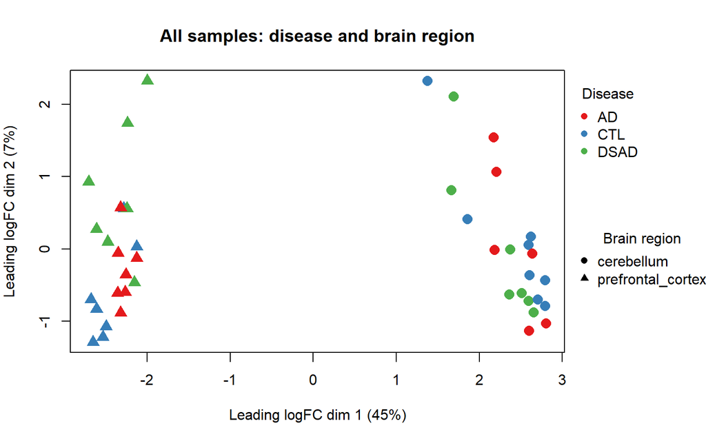

Dim 1 (45% variance) separates cerebellum from prefrontal cortex cleanly; disease groups show no comparable separation.  
→ Continuing with analyses split by region; paired design used for cross-tissue comparison.

## AD vs CTL: No FDR-Significant Genes in Either Region

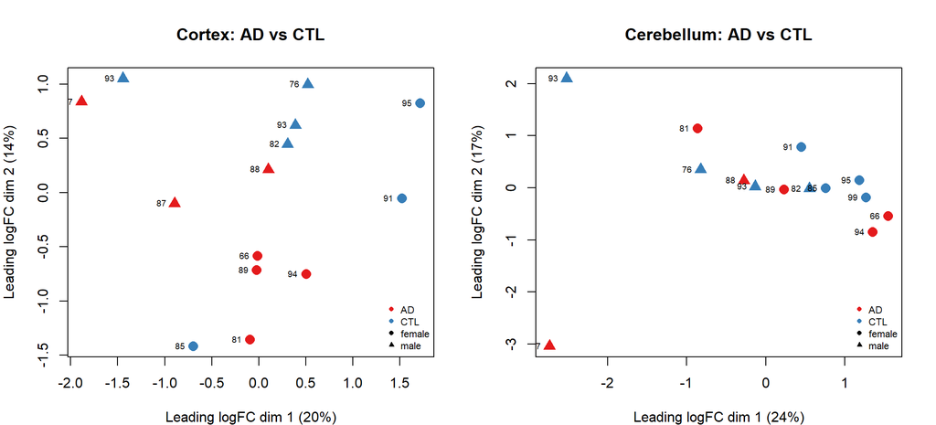

- **0 FDR-significant genes in either region**, age + sex adjusted (cortex: 7 AD vs 7 CTL; cerebellum: 6 AD vs 8 CTL)
- Top nominal prefrontal cortex hits: VGF↓, CRH↓, SCG3↓ (neuroendocrine/synaptic)
- Top nominal cerebellum hits: entirely non-overlapping with cortex
- Consistent with known AD/aging transcriptional overlap in bulk tissue
- *DSAD excluded from single-region analyses — site (UCI vs USC) fully confounded with group; addressed separately via paired cross-tissue model*

## Braak Gradient in Prefrontal Cortex

Binary AD vs CTL comparison yielded 0 FDR-significant genes — Braak stage (0→6) tested as a continuous severity predictor to increase power. Age and sex adjusted · CTL + AD · n=14  
*(DSAD excluded: all Braak 6, no severity gradient)*

**Result: still no FDR-significant genes**

Top nominal hits nonetheless consistent with AD vs CTL: VGF↓, SCG2↓, SCG3↓ — neuroendocrine/synaptic genes declining with pathology severity in prefrontal cortex, not in cerebellum

Convergent evidence across two analytical approaches — the signal exists but is below detection threshold at this sample size

## Cross-Tissue Interaction: DSAD Regional Signature

Within-person prefrontal cortex − cerebellum difference vs CTL  
*(19 complete pairs: CTL n=7, AD n=6, DSAD n=6)*

| Contrast | Down | Up | Total sig. genes |
| --- | --- | --- | --- |
| AD region effect | 0 | 2 | 2 |
| DSAD region effect | 883 | 662 | **1545** |

DSAD disrupts the normal cortex-cerebellum expression relationship massively.  
Sporadic AD does not, despite similar Braak scores in the most severe AD cases.

**Top DSAD-specific hits**: KIF5A (axonal transport), TSC2 (mTOR/autophagy),  
PEX6 (peroxisomal biogenesis), RAPGEF4 (vesicle trafficking)  
→ convergent on endosomal-lysosomal-autophagy axis

*Paired design: individual-level confounds (genetics, PMI, site) cancel within pairs*

## DSAD Region Effect: Volcano

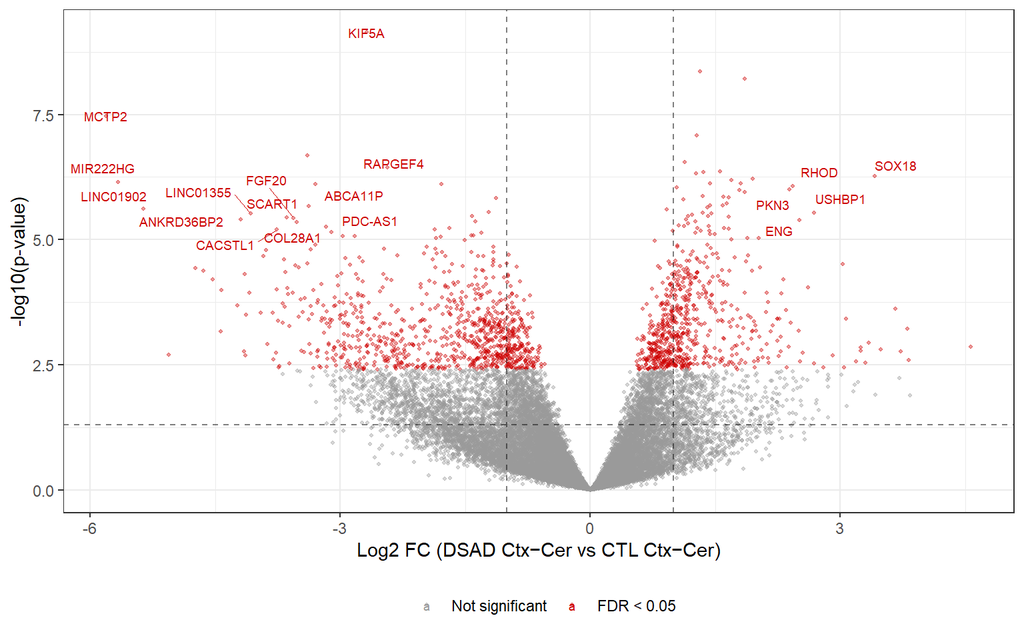

## DSAD Regional Disruption: Pathway Enrichment

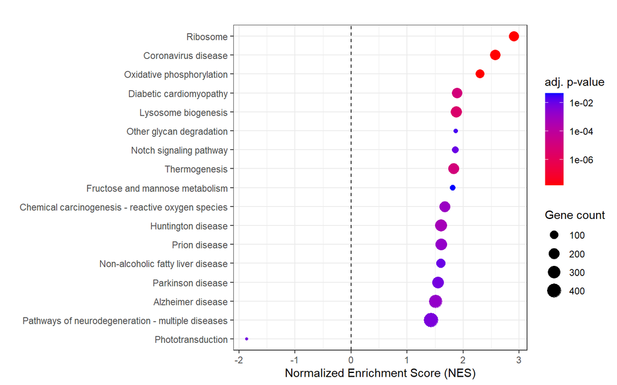

*Within-person prefrontal cortex−cerebellum difference vs CTL*  
*NES > 0: upregulated in DSAD · NES < 0: downregulated · Color = adjusted p-value*

## DSAD Regional Disruption: Pathway Interpretation

16 upregulated pathways dominated by **ribosomal/mitochondrial stress**  
(Ribosome, Oxidative phosphorylation) and **neurodegeneration-relevant** pathways:

- **Lysosome biogenesis**, matching the KIF5A/TSC2/PEX6 individual gene hits
- **Alzheimer disease pathway**: directly relevant
- **Reactive oxygen species**, echoing Thorwald et al.’s ferroptosis findings at the protein level

1 downregulated: **Phototransduction** (cerebellar signaling genes), relatively suppressed in DSAD prefrontal cortex

→ Transcriptomic pathway disruption converges on the same oxidative stress  
and proteostasis mechanisms reported at protein level in the companion paper

## Connection to Published Analysis

|  | Thorwald et al. 2025 | This reanalysis |
| --- | --- | --- |
| CTL vs AD PFC | 10 DEGs (incl. VGF) | 0 FDR-sig (VGF top nominal) |
| CTL vs AD cerebellum | 1374 DEGs | 0 FDR-significant |
| Region overlap | None (all comparisons) | None confirmed (AD vs CTL + Braak gradient) |
| Pathway analysis | IPA (commercial) | clusterProfiler GSEA (open source) |
| Braak gradient | Not done | Region-specific signatures |
| Cross-tissue interaction | Not done | 1545 DSAD-specific genes |

*Discrepancy in CTL vs AD cerebellum (1374 vs 0): Thorwald et al. applied RUVSeq correction (parameters unreported) and DESeq2 without stated age adjustment or FDR threshold, so a full comparison isn’t possible without complete methodological details*

## Limitations

- 7-8 donors/group, and only 6 complete pairs per disease group: low power; no FDR-significant genes in AD vs CTL
- DSAD samples come from a different site (UCI vs USC), confounded with group, age, and PMI; unresolvable in this design
- Bulk RNA-seq dilutes cell-type-specific signals, so microglial activation isn’t detectable